# Functional connectivity-based classification of autism and control using SVM-RFECV on rs-fMRI data - ScienceDirect

## Outline

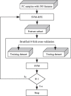

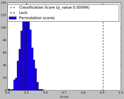

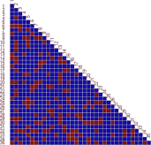

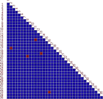

## [Physica Medica](https://www.sciencedirect.com/science/journal/11201797)

[Volume 65](https://www.sciencedirect.com/science/journal/11201797/65/supp/C), September 2019, Pages 99-105

# Original paper Functional connectivity-based classification of autism and control using SVM-RFECV on rs-fMRI data

## Highlights

**•**

The proposed method improves the identification of [autism](https://www.sciencedirect.com/topics/medicine-and-dentistry/pervasive-developmental-disorder) on resting-state functional magnetic imaging data.

**•**

The most discriminative feature subset about [functional connectivity](https://www.sciencedirect.com/topics/medicine-and-dentistry/functional-connectivity) in the brain of autism was found.

**•**

The classification accuracy obtained is better than the recent similar studies.

**•**

The results can be used as an important reference for autism diagnoses.

## Abstract

Considering the unsatisfactory classification accuracy of autism due to unsuitable features selected in current studies, a functional connectivity (FC)-based algorithm for classifying autism and control using support vector machine-recursive feature elimination (SVM-RFE) is proposed in this paper. The goal is to find the optimal features based on FC and improve the classification accuracy on a large sample of data. We chose 35 regions of interest based on the social motivation hypothesis to construct the FC matrix and searched for informative features in the complex high-dimensional FC dataset by the SVM-RFE with a stratified-4-fold cross-validation strategy. The selected features were then entered into an SVM with a Gaussian kernel for classification. A total of 255 subjects with autism and 276 subjects with typical development from 10 sites were involved in the study. For the data of global sites, the proposed classification algorithm could identify the two groups with an accuracy of 90.60% (sensitivity 90.62%, specificity 90.58%). For the leave-one-site-out test, the proposed algorithm achieved a classification accuracy of 75.00%–95.23% for data from different sites. These promising results demonstrate that the proposed classification algorithm performs better than those in recent similar studies in that the importance of features can be measured accurately and only the most discriminative feature subset is selected.

## Keywords

Autism

fMRI

Feature selection

Machine learning

Classification

© 2019 Associazione Italiana di Fisica Medica. Published by Elsevier Ltd. All rights reserved.